# Clustering and Classification

Our next exercise uses on the ready dataset available, the Boston-dataset. This dataset has information on the city of Boston with descriptive variables for observed suburbs.

```r
library(MASS)
library("ggplot2")
library("GGally")
library("corrplot")
library("tidyverse")
library("vtable")
data("Boston")
str(Boston)
```

```
## 'data.frame':    506 obs. of  14 variables:
##  $ crim   : num  0.00632 0.02731 0.02729 0.03237 0.06905 ...
##  $ zn     : num  18 0 0 0 0 0 12.5 12.5 12.5 12.5 ...
##  $ indus  : num  2.31 7.07 7.07 2.18 2.18 2.18 7.87 7.87 7.87 7.87 ...
##  $ chas   : int  0 0 0 0 0 0 0 0 0 0 ...
##  $ nox    : num  0.538 0.469 0.469 0.458 0.458 0.458 0.524 0.524 0.524 0.524 ...
##  $ rm     : num  6.58 6.42 7.18 7 7.15 ...
##  $ age    : num  65.2 78.9 61.1 45.8 54.2 58.7 66.6 96.1 100 85.9 ...
##  $ dis    : num  4.09 4.97 4.97 6.06 6.06 ...
##  $ rad    : int  1 2 2 3 3 3 5 5 5 5 ...
##  $ tax    : num  296 242 242 222 222 222 311 311 311 311 ...
##  $ ptratio: num  15.3 17.8 17.8 18.7 18.7 18.7 15.2 15.2 15.2 15.2 ...
##  $ black  : num  397 397 393 395 397 ...
##  $ lstat  : num  4.98 9.14 4.03 2.94 5.33 ...
##  $ medv   : num  24 21.6 34.7 33.4 36.2 28.7 22.9 27.1 16.5 18.9 ...
```

```r
dim(Boston)
```

```
## [1] 506  14
```

There are 506 observations with 14 different variables.

| Variable | Explanation |
| --- | --- |
| rim | per capita crime rate by town |
| zn | proportion of residential land zoned for lots over 25,000 sq.ft. |
| indus | proportion of non-retail business acres per town |
| chas | Charles River dummy variable (= 1 if tract bounds river; 0 otherwise) |
| nox | nitrogen oxides concentration (parts per 10 million) |
| rm | average number of rooms per dwelling |
| age | proportion of owner-occupied units built prior to 1940 |
| dis | weighted mean of distances to five Boston employment centres |
| rad | index of accessibility to radial highways |
| tax | full-value property-tax rate per $10,000 |
| ptratio | pupil-teacher ratio by town |
| black | 1000(Bk - 0.63)^2 where Bk is the proportion of blacks by town |
| lstat | lower status of the population (percent) |
| medv | median value of owner-occupied homes in $1000s |

Information on variables from https://stat.ethz.ch/R-manual/R-devel/library/MASS/html/Boston.html

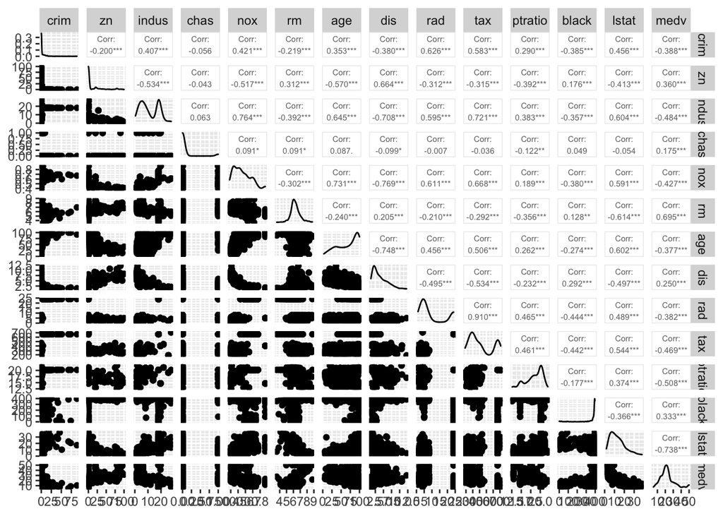

```r
ggpairs(Boston, upper = list(continuous = wrap('cor', size = 2)))
```

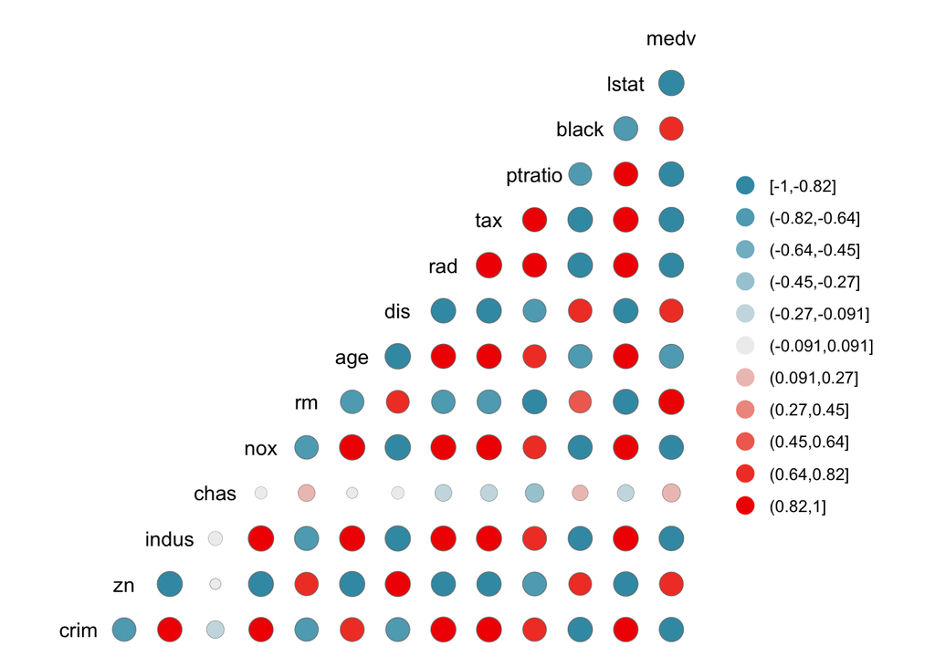

```r
ggcorr(cor(Boston), geom = "circle", nbreaks = 11)
```

```r
sumtable(Boston)
```

Summary Statistics

| Variable | N | Mean | Std. Dev. | Min | Pctl. 25 | Pctl. 75 | Max |
| --- | --- | --- | --- | --- | --- | --- | --- |
| crim | 506 | 3.614 | 8.602 | 0.006 | 0.082 | 3.677 | 88.976 |
| zn | 506 | 11.364 | 23.322 | 0 | 0 | 12.5 | 100 |
| indus | 506 | 11.137 | 6.86 | 0.46 | 5.19 | 18.1 | 27.74 |
| chas | 506 | 0.069 | 0.254 | 0 | 0 | 0 | 1 |
| nox | 506 | 0.555 | 0.116 | 0.385 | 0.449 | 0.624 | 0.871 |
| rm | 506 | 6.285 | 0.703 | 3.561 | 5.886 | 6.624 | 8.78 |
| age | 506 | 68.575 | 28.149 | 2.9 | 45.025 | 94.075 | 100 |
| dis | 506 | 3.795 | 2.106 | 1.13 | 2.1 | 5.188 | 12.126 |
| rad | 506 | 9.549 | 8.707 | 1 | 4 | 24 | 24 |
| tax | 506 | 408.237 | 168.537 | 187 | 279 | 666 | 711 |
| ptratio | 506 | 18.456 | 2.165 | 12.6 | 17.4 | 20.2 | 22 |
| black | 506 | 356.674 | 91.295 | 0.32 | 375.378 | 396.225 | 396.9 |
| lstat | 506 | 12.653 | 7.141 | 1.73 | 6.95 | 16.955 | 37.97 |
| medv | 506 | 22.533 | 9.197 | 5 | 17.025 | 25 | 50 |

From the summary statistics we can observe that the variables have wide range of values, chas is only a twofold category with values 0 or 1, to a range of 0 to 400 (black population proportion). With the exception of chas, most of the variables seem to have fairly strong correlations with at least some of the other values.

```r
bsca <- scale(Boston)
bsca <- as.data.frame(bsca)
sumtable(bsca, add.median = TRUE)
```

Summary Statistics

| Variable | N | Mean | Std. Dev. | Min | Pctl. 25 | Pctl. 50 | Pctl. 75 | Max |
| --- | --- | --- | --- | --- | --- | --- | --- | --- |
| crim | 506 | 0 | 1 | -0.419 | -0.411 | -0.39 | 0.007 | 9.924 |
| zn | 506 | 0 | 1 | -0.487 | -0.487 | -0.487 | 0.049 | 3.8 |
| indus | 506 | 0 | 1 | -1.556 | -0.867 | -0.211 | 1.015 | 2.42 |
| chas | 506 | 0 | 1 | -0.272 | -0.272 | -0.272 | -0.272 | 3.665 |
| nox | 506 | 0 | 1 | -1.464 | -0.912 | -0.144 | 0.598 | 2.73 |
| rm | 506 | 0 | 1 | -3.876 | -0.568 | -0.108 | 0.482 | 3.552 |
| age | 506 | 0 | 1 | -2.333 | -0.837 | 0.317 | 0.906 | 1.116 |
| dis | 506 | 0 | 1 | -1.266 | -0.805 | -0.279 | 0.662 | 3.957 |
| rad | 506 | 0 | 1 | -0.982 | -0.637 | -0.522 | 1.66 | 1.66 |
| tax | 506 | 0 | 1 | -1.313 | -0.767 | -0.464 | 1.529 | 1.796 |
| ptratio | 506 | 0 | 1 | -2.705 | -0.488 | 0.275 | 0.806 | 1.637 |
| black | 506 | 0 | 1 | -3.903 | 0.205 | 0.381 | 0.433 | 0.441 |
| lstat | 506 | 0 | 1 | -1.53 | -0.799 | -0.181 | 0.602 | 3.545 |
| medv | 506 | 0 | 1 | -1.906 | -0.599 | -0.145 | 0.268 | 2.987 |

```r
# Create quatiles from crim value as separate categories
crime <- cut(bsca$crim, breaks = quantile(bsca$crim), label =c("low","med_low", "med_high", "high"), include.lowest = TRUE)
bsca <- dplyr::select(bsca, -crim)
bsca <- data.frame(bsca, crime)

# Create test and training sets (80 % to train set)
ind <- sample(nrow(bsca),  size = nrow(bsca) * 0.8)
train <- bsca[ind,]
test <- bsca[-ind,]

# Copy correct crme categories from test set and remove from set
correct_classes <- test$crime
test <- dplyr::select(test, -crime)
```

```r
# Shamelessly copied from Datacamp excercise

# linear discriminant analysis
lda.fit <- lda(crime ~ ., data = train)

# print the lda.fit object
lda.fit
```

```
## Call:
## lda(crime ~ ., data = train)
##
## Prior probabilities of groups:
##       low   med_low  med_high      high
## 0.2574257 0.2475248 0.2400990 0.2549505
##
## Group means:
##                  zn      indus        chas        nox          rm        age
## low       0.8800870 -0.8762654 -0.08304540 -0.8534602  0.47158881 -0.8429736
## med_low  -0.1161386 -0.3111471 -0.07547406 -0.5508055 -0.10185403 -0.2713041
## med_high -0.3882249  0.2175844  0.13355755  0.3244249  0.03231606  0.4047460
## high     -0.4872402  1.0170891 -0.23410479  1.0282360 -0.39763043  0.7856584
##                 dis        rad        tax    ptratio      black       lstat
## low       0.8235375 -0.6936501 -0.7709820 -0.4320392  0.3854239 -0.76557323
## med_low   0.2845251 -0.5626807 -0.5093665 -0.1124895  0.3566254 -0.12822509
## med_high -0.3569736 -0.4325014 -0.3167343 -0.2213658  0.1095870  0.03020554
## high     -0.8346367  1.6384176  1.5142626  0.7811136 -0.7122068  0.87567478
##                 medv
## low       0.54792346
## med_low   0.03285748
## med_high  0.15594082
## high     -0.73511853
##
## Coefficients of linear discriminants:
##                 LD1         LD2         LD3
## zn       0.10964227  0.76363730 -0.90156003
## indus    0.03735388 -0.27162554  0.08584044
## chas    -0.04636959 -0.12270688 -0.04734585
## nox      0.36874576 -0.55330685 -1.53385079
## rm       0.05172679  0.04796301 -0.14808397
## age      0.23920974 -0.28704906 -0.10223084
## dis     -0.10400508 -0.21183314 -0.05778611
## rad      3.36437158  1.11385577  0.05743351
## tax      0.05734359 -0.33500859  0.58602536
## ptratio  0.08691724  0.07347805 -0.41419416
## black   -0.10243201  0.03757008  0.20065143
## lstat    0.19150578 -0.28186802  0.31615241
## medv     0.02677828 -0.48207225 -0.37090905
##
## Proportion of trace:
##    LD1    LD2    LD3
## 0.9585 0.0315 0.0100
```

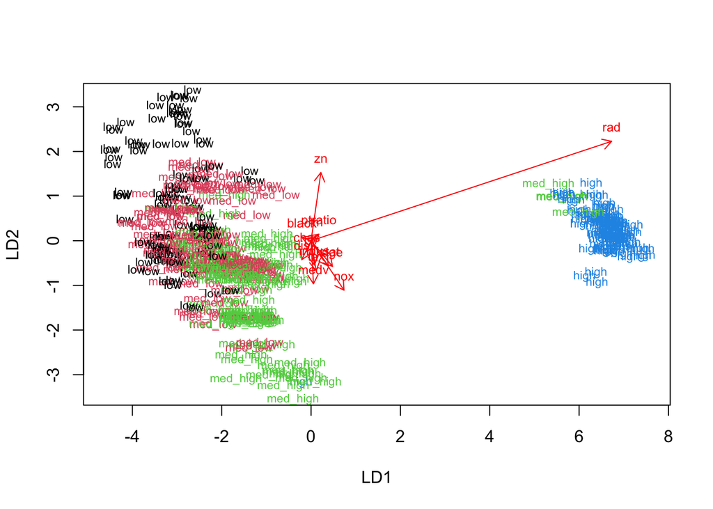

```r
# the function for lda biplot arrows
lda.arrows <- function(x, myscale = 1, arrow_heads = 0.1, color = "red", tex = 0.75, choices = c(1,2)){
  heads <- coef(x)
  arrows(x0 = 0, y0 = 0,
         x1 = myscale * heads[,choices[1]],
         y1 = myscale * heads[,choices[2]], col=color, length = arrow_heads)
  text(myscale * heads[,choices], labels = row.names(heads),
       cex = tex, col=color, pos=3)
}

# target classes as numeric
classes <- as.numeric(train$crime)

# plot the lda results
plot(lda.fit, dimen = 2,col = classes, pch = classes)
lda.arrows(lda.fit, myscale = 2)
```

From the biplot and also quite easily from the coefficients list on the linear discriminats output we can see that rad variable, aka. index of accessibility to radial highways, has a very strong correlation for high crimes rates.

For the lower three categories of crime, it seems that area with larger plots sizes have lower crime rates. Also the nitrogen oxide concentration seems to a have similar but reverse effect (higher concentration, more crime).

```r
# predict classes with test data
lda.pred <- predict(lda.fit, newdata = test)

# cross tabulate the results
table(correct = correct_classes, predicted = lda.pred$class)
```

```
##           predicted
## correct    low med_low med_high high
##   low       16       7        0    0
##   med_low    7      15        4    0
##   med_high   0       8       19    2
##   high       0       0        0   24
```

The generated model seems to predict higher crime rate areas better. The highest being clear a separate cluster in the biplot most likely explains this and the three other categories there is more variance in the predict-algorithms results.

```r
# Need to redo scaling version for K-mean to work
bsca <- scale(Boston)
dist_euclidian <- dist(bsca)
summary(dist_euclidian)
```

```
##    Min. 1st Qu.  Median    Mean 3rd Qu.    Max.
##  0.1343  3.4625  4.8241  4.9111  6.1863 14.3970
```

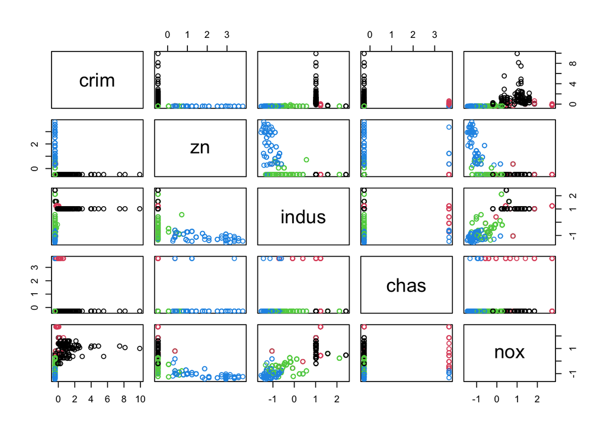

```r
kc <- 6
km <- kmeans(bsca, centers = 4)
TWCSS <- sapply(1:kc, function(k){kmeans(Boston, k)$tot.withinss})
bsca <- as.data.frame(bsca)
pairs(bsca[1:5], col = km$cluster)
```

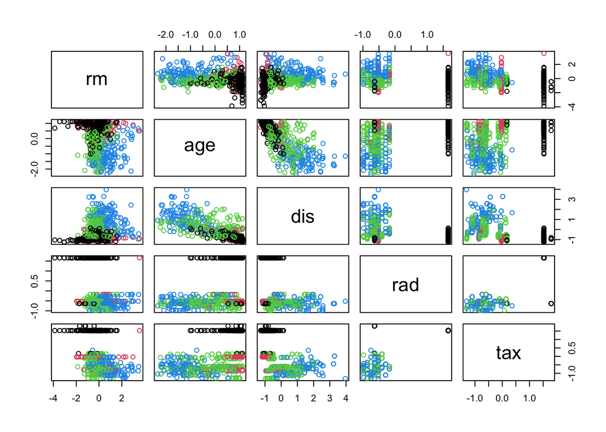

```r
pairs(bsca[6:10], col = km$cluster)
```

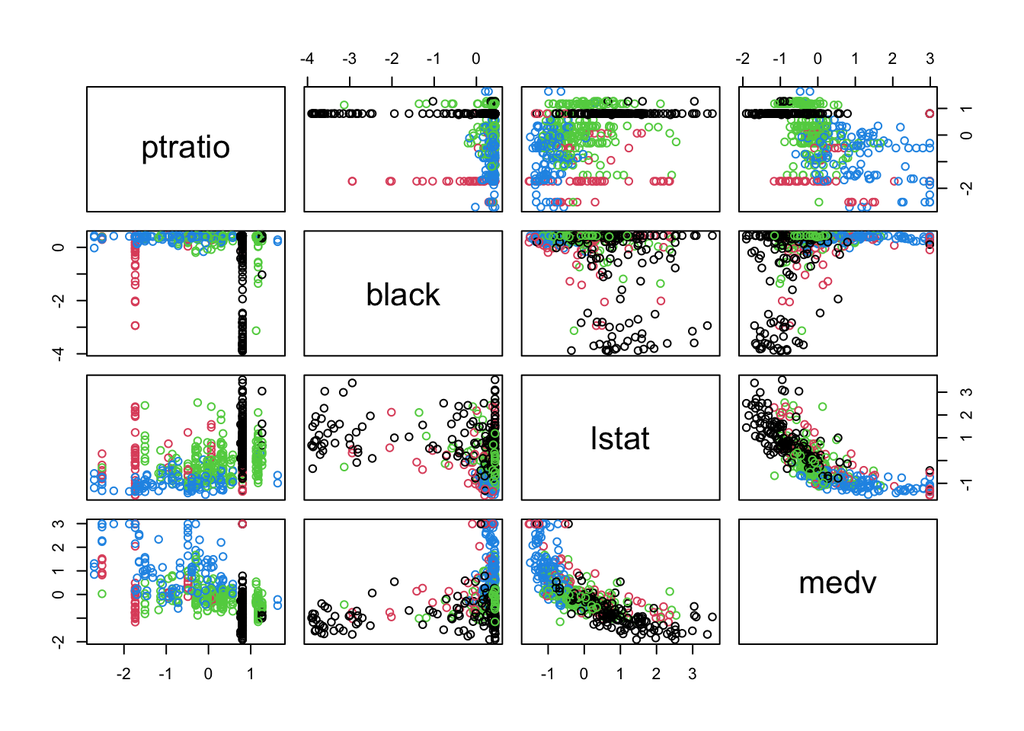

```r
pairs(bsca[11:14], col = km$cluster)
```

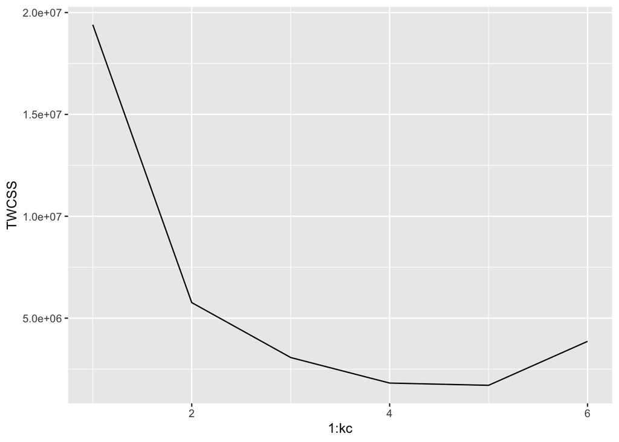

```r
qplot(x = 1:kc, y = TWCSS, geom = 'line')
```

Looking the paired data or the more informative total of within cluster sum of squares plot we can see that clustering to two groups would capture most differences in the variables.